# Wine

Mike McPhee Anderson

December 24, 2018

## Wine

The wine data is a high-dimensional dataset with 3 classes for prediction. The objective is to predict the class (i.e. type of wine, labeled 1 through 3) based on 13 continuous attributes representing measurements of various chemical properties of the wine.

## Visualization

Since the data is highly dimensional, visualization will be difficult. We’ll throw the kitchen sink at it and do pair-plots.

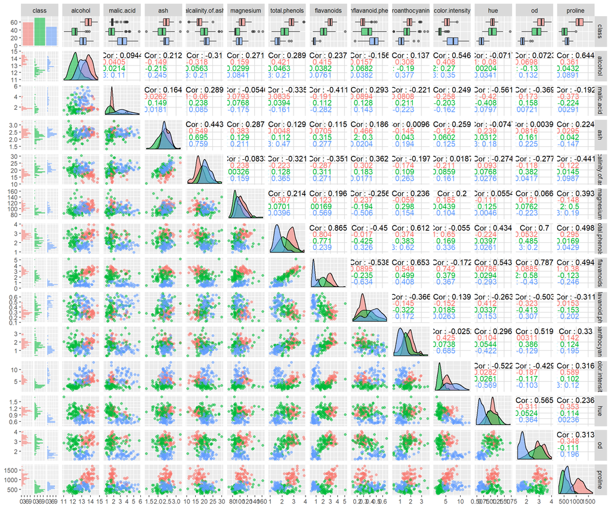

```r
ggpairs(wine, aes(color=class, alpha=0.65))
```

### Basic Visualization

Looking at the above plot, *alcohol* and *od* seem to form a decent decision boundary, so does *flavanoid* and *proline*. We’ll eye-ball some boundaries and add them to the graph (black lines).

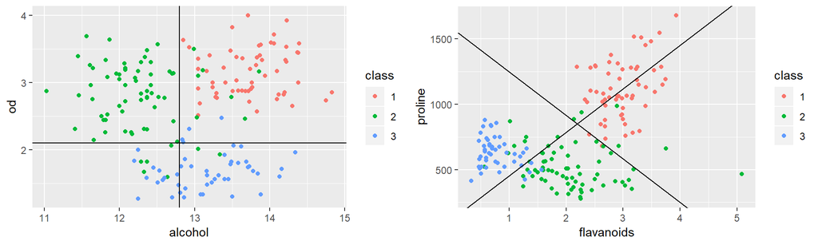

```r
plot.alcohol.vs.od <- ggplot(wine, aes(x=alcohol, y=od, color=class)) +
    geom_point() +
    geom_hline(yintercept = 2.1) +
    geom_vline(xintercept = 12.8)

plot.flav.vs.proline <- ggplot(wine, aes(x=flavanoids, y=proline, color=class)) +
    geom_point() +
    geom_abline(intercept = 1580, slope = -(1500/4.5)) +
    geom_abline(intercept = 120, slope = (1500/4.5))

grid.arrange(plot.alcohol.vs.od, plot.flav.vs.proline, ncol=2)
```

The first plot (od vs. alcohol) looks to form a pretty straight-forward decision boundary, but the second would be a struggle with a decision-tree. It seems that a rotation could fix it, since the decision boundary is on a line. We’ll perform an SVD to (hopefully) remove this rotation, and plot the resulting points.

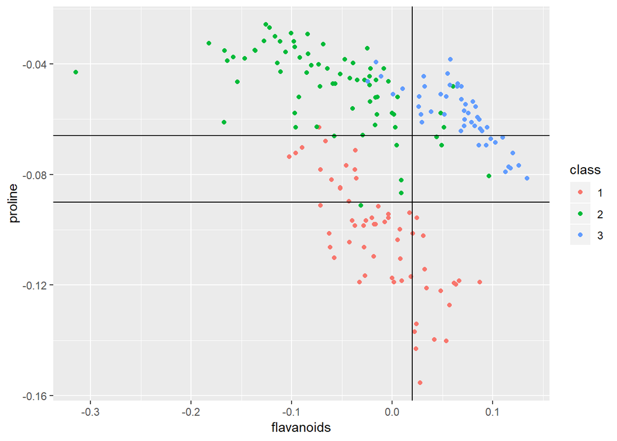

```r
# rotate the proline / flavanoid plot to make a cleaner decision boundary (horizontal / vertical lines)
plot2Rot <- svd(cbind(wine$proline, wine$flavanoids))
plot2Translated <- as.data.frame(cbind(plot2Rot$u, wine$class))
names(plot2Translated) <- c("proline", "flavanoids", "class")

plot2Translated$class <- as.factor(plot2Translated$class)

ggplot(plot2Translated, aes(x=flavanoids, y=proline, color=class)) +
  geom_point() +
  geom_hline(yintercept = -0.066) +
  geom_vline(xintercept = 0.02) +
  geom_hline(yintercept = -0.09)
```

Looks like we got some pretty good sepearation, although not a clean as we probably could get with a manual rotation. Adding another region seems to fix it though, so this might still be a good candidate for a decision tree.

### Advanced Visualization

The SVD factorization is applied during PCA. It might be interesting to visualize the pricipal components.

```r
wine.M <- as.matrix(wine[ , 2:14])
wine.prComp <- prcomp(wine.M)

summary(wine.prComp)
```

```
## Importance of components:
##                             PC1      PC2     PC3     PC4     PC5     PC6
## Standard deviation     314.9632 13.13527 3.07215 2.23409 1.10853 0.91710
## Proportion of Variance   0.9981  0.00174 0.00009 0.00005 0.00001 0.00001
## Cumulative Proportion    0.9981  0.99983 0.99992 0.99997 0.99998 0.99999
##                           PC7    PC8    PC9   PC10   PC11   PC12    PC13
## Standard deviation     0.5282 0.3891 0.3348 0.2678 0.1938 0.1452 0.09057
## Proportion of Variance 0.0000 0.0000 0.0000 0.0000 0.0000 0.0000 0.00000
## Cumulative Proportion  1.0000 1.0000 1.0000 1.0000 1.0000 1.0000 1.00000
```

Judging by the cumulative proportion… that worked pretty well. Let’s take a look at a pair plot of the principal components.

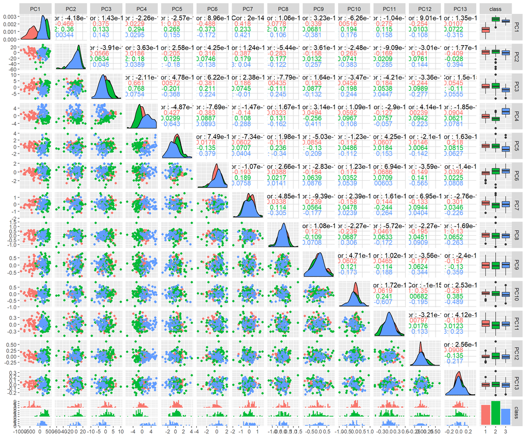

```r
wine.pca <- as.data.frame(cbind(wine.prComp$x, class=wine$class))

wine.pca$class = as.factor(wine.pca$class)

ggpairs(wine.pca, aes(color=class))
```

It looks like there might be a couple candidates for good decision boundaries. The first principal component does an OK job separating red from the others, and the fourth does a good job of separating gree from blue. Looking at them together looks decent, but not great.

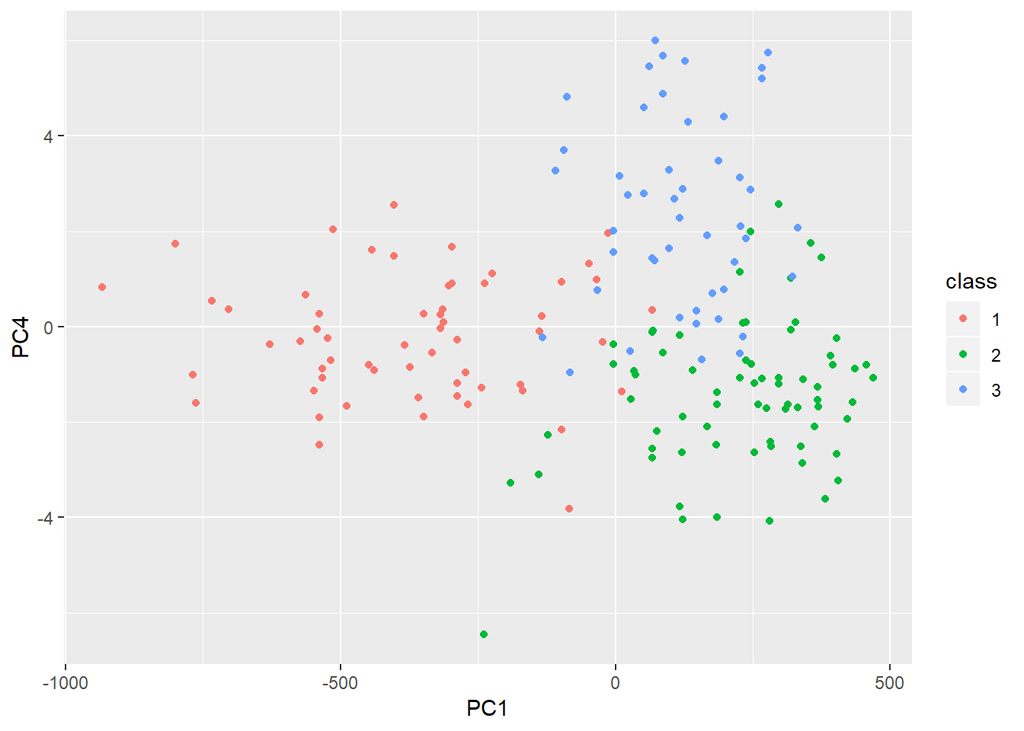

```r
ggplot(wine.pca, aes(x=PC1, y=PC4, color=class)) +
  geom_point()
```

## Feature Selection

Although some feature look promising from visualization, it might be a good idea to try some automated feature selection too. First we should get a feel for which features (if any) are highly correlated.

```r
cor(wine[,2:ncol(wine)])
```

```
##                         alcohol  malic.acid          ash alcalinity.of.ash
## alcohol              1.00000000  0.09439694  0.211544596       -0.31023514
## malic.acid           0.09439694  1.00000000  0.164045470        0.28850040
## ash                  0.21154460  0.16404547  1.000000000        0.44336719
## alcalinity.of.ash   -0.31023514  0.28850040  0.443367187        1.00000000
## magnesium            0.27079823 -0.05457510  0.286586691       -0.08333309
## total.phenols        0.28910112 -0.33516700  0.128979538       -0.32111332
## flavanoids           0.23681493 -0.41100659  0.115077279       -0.35136986
## nonflavanoid.phenol -0.15592947  0.29297713  0.186230446        0.36192172
## proanthocyanins      0.13669791 -0.22074619  0.009651935       -0.19732684
## color.intensity      0.54636420  0.24898534  0.258887259        0.01873198
## hue                 -0.07174720 -0.56129569 -0.074666889       -0.27395522
## od                   0.07234319 -0.36871043  0.003911231       -0.27676855
## proline              0.64372004 -0.19201056  0.223626264       -0.44059693
##                       magnesium total.phenols flavanoids
## alcohol              0.27079823    0.28910112  0.2368149
## malic.acid          -0.05457510   -0.33516700 -0.4110066
## ash                  0.28658669    0.12897954  0.1150773
## alcalinity.of.ash   -0.08333309   -0.32111332 -0.3513699
## magnesium            1.00000000    0.21440123  0.1957838
## total.phenols        0.21440123    1.00000000  0.8645635
## flavanoids           0.19578377    0.86456350  1.0000000
## nonflavanoid.phenol -0.25629405   -0.44993530 -0.5378996
## proanthocyanins      0.23644061    0.61241308  0.6526918
## color.intensity      0.19995001   -0.05513642 -0.1723794
## hue                  0.05539820    0.43368134  0.5434786
## od                   0.06600394    0.69994936  0.7871939
## proline              0.39335085    0.49811488  0.4941931
##                     nonflavanoid.phenol proanthocyanins color.intensity
## alcohol                      -0.1559295     0.136697912      0.54636420
## malic.acid                    0.2929771    -0.220746187      0.24898534
## ash                           0.1862304     0.009651935      0.25888726
## alcalinity.of.ash             0.3619217    -0.197326836      0.01873198
## magnesium                    -0.2562940     0.236440610      0.19995001
## total.phenols                -0.4499353     0.612413084     -0.05513642
## flavanoids                   -0.5378996     0.652691769     -0.17237940
## nonflavanoid.phenol           1.0000000    -0.365845099      0.13905701
## proanthocyanins              -0.3658451     1.000000000     -0.02524993
## color.intensity               0.1390570    -0.025249931      1.00000000
## hue                          -0.2626396     0.295544253     -0.52181319
## od                           -0.5032696     0.519067096     -0.42881494
## proline                      -0.3113852     0.330416700      0.31610011
##                             hue           od    proline
## alcohol             -0.07174720  0.072343187  0.6437200
## malic.acid          -0.56129569 -0.368710428 -0.1920106
## ash                 -0.07466689  0.003911231  0.2236263
## alcalinity.of.ash   -0.27395522 -0.276768549 -0.4405969
## magnesium            0.05539820  0.066003936  0.3933508
## total.phenols        0.43368134  0.699949365  0.4981149
## flavanoids           0.54347857  0.787193902  0.4941931
## nonflavanoid.phenol -0.26263963 -0.503269596 -0.3113852
## proanthocyanins      0.29554425  0.519067096  0.3304167
## color.intensity     -0.52181319 -0.428814942  0.3161001
## hue                  1.00000000  0.565468293  0.2361834
## od                   0.56546829  1.000000000  0.3127611
## proline              0.23618345  0.312761075  1.0000000
```

*od* is pretty correlated with *total.phenols*, *flavanoids*, and *hue*. *proanthocyanins* stands out as having a few highly correlated other variables as well. This suggests that we should use the “big-guns” to help with feature selection. The caret pacakge has some functionality to help with this.

```r
trCtrl <- trainControl(method="repeatedcv", number=5, repeats=3)
lvqFit <- train(class~., data=wine, method="lvq", preProcess="scale", trControl=trCtrl)

lvqFitImportance <- varImp(lvqFit, scale=FALSE)

print(lvqFitImportance)
```

```
## ROC curve variable importance
##
##   variables are sorted by maximum importance across the classes
##                         X1     X2     X3
## od                  1.0000 0.9652 1.0000
## flavanoids          1.0000 0.9721 1.0000
## hue                 0.9868 0.9544 0.9868
## proline             0.9866 0.9866 0.9806
## total.phenols       0.9845 0.8170 0.9845
## color.intensity     0.9468 0.9756 0.9756
## alcohol             0.9739 0.9739 0.8797
## proanthocyanins     0.9170 0.7796 0.9170
## alcalinity.of.ash   0.9103 0.7917 0.9103
## nonflavanoid.phenol 0.8388 0.6926 0.8388
## malic.acid          0.8347 0.8355 0.8355
## magnesium           0.8072 0.8072 0.6865
## ash                 0.7137 0.7137 0.7116
```

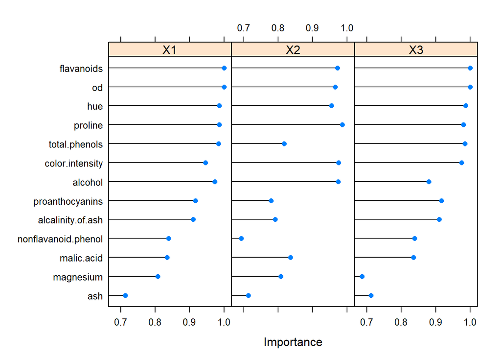

```r
plot(lvqFitImportance)
```

The results suggest elimninating a couple variables. Next, we’ll check the PCA as well.

```r
trCtrl <- trainControl(method="repeatedcv", number=5, repeats=3)
lvqFit <- train(class~., data=wine.pca, method="lvq", trControl=trCtrl)

lvqFitImportance <- varImp(lvqFit, scale=FALSE)

print(lvqFitImportance)
```

```
## ROC curve variable importance
##
##   variables are sorted by maximum importance across the classes
##          X1     X2     X3
## PC1  0.9869 0.9869 0.9809
## PC4  0.8619 0.9487 0.9487
## PC3  0.8270 0.8093 0.8270
## PC5  0.7521 0.7251 0.7521
## PC6  0.6882 0.6756 0.6882
## PC7  0.6598 0.6598 0.5772
## PC2  0.5658 0.6203 0.6203
## PC10 0.6137 0.5613 0.6137
## PC11 0.5870 0.5870 0.5737
## PC8  0.5611 0.5460 0.5611
## PC12 0.5371 0.5531 0.5531
## PC13 0.5290 0.5425 0.5425
## PC9  0.5211 0.5211 0.5161
```

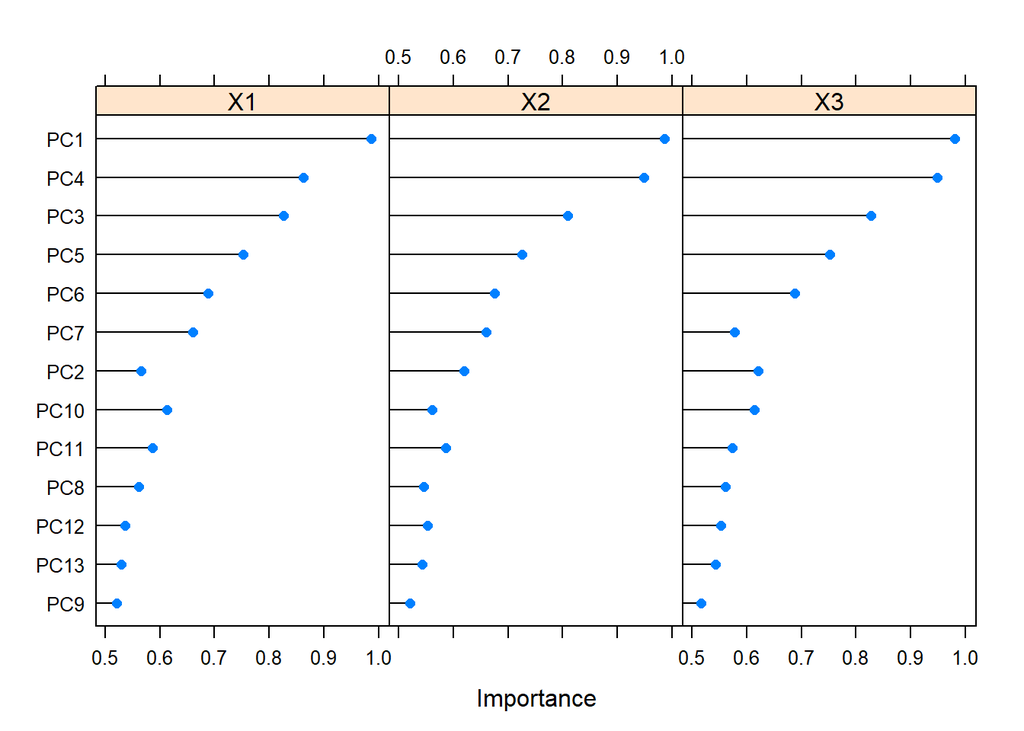

```r
plot(lvqFitImportance)
```

PCA did it’s job, we can probably get away with using about half the principal componenets. Consistent with our analysis above, the first and fourth principal components look pretty important. Components 3, 5, and 6 look pretty important too.

## Baseline Model

We’ll holdout 20% of the training set for testing (stratified).

```r
wine$svd.flavanoids = plot2Translated$flavanoids
wine$svd.proline = plot2Translated$proline
wine <- cbind(wine, wine.pca[, 1:13])


# create holdout set
trainIdx <- as.vector(
  createDataPartition(wine$class, p=.80, list=FALSE))

wine.train <- wine[trainIdx,]
wine.test <- wine[-trainIdx,]
```

First we’ll attempt a decision tree model on *od*, *alcohol*, *flavanoid*, and *proline*. We’ll do this using the non-transformed (via SVD) data first.

```r
set.seed(142)

# four folds
trCtrl <- trainControl(method="repeatedcv", number=8, repeats = 3)

# tuneLength is the number of attempts made to adjust the model's "tuning" parameter,
# in this case it is the "complexity" of the decision tree, e.g. gini information gain
treeFit <- train(class ~ od + alcohol + flavanoids + proline, data=wine.train,
                 method="rpart",
                 trControl=trCtrl,
                 tuneLength=10)

confusionMatrix(treeFit)
```

```
## Cross-Validated (8 fold, repeated 3 times) Confusion Matrix
##
## (entries are percentual average cell counts across resamples)
##
##           Reference
## Prediction    1    2    3
##          1 29.6  2.3  0.0
##          2  3.2 31.5  4.4
##          3  0.5  5.8 22.7
##
##  Accuracy (average) : 0.838
```

The results are not great, let’s try with the svd translated flavanoids and svd.

```r
set.seed(142)

# four folds
trCtrl <- trainControl(method="repeatedcv", number=8, repeats = 3)

# tuneLength is the number of attempts made to adjust the model's "tuning" parameter,
# in this case it is the "complexity" of the decision tree, e.g. gini information gain
treeFit <- train(class ~ od + alcohol + svd.flavanoids + svd.proline, data=wine.train,
                 method="rpart",
                 trControl=trCtrl,
                 tuneLength=10)

confusionMatrix(treeFit)
```

```
## Cross-Validated (8 fold, repeated 3 times) Confusion Matrix
##
## (entries are percentual average cell counts across resamples)
##
##           Reference
## Prediction    1    2    3
##          1 28.5  2.5  0.7
##          2  4.4 32.2  2.3
##          3  0.5  4.9 24.1
##
##  Accuracy (average) : 0.8472
```

Suprisingly, this has little effect on accuracy. Let’s re-attempt this with SVM.

```r
set.seed(142)

# four folds
trCtrl <- trainControl(method="repeatedcv", number=8, repeats = 3)

trGrid <- expand.grid(C=seq(0.05, 1.5, .1))

# tuneLength is the number of attempts made to adjust the model's "tuning" parameter,
# in this case it is the "complexity" of the decision tree, e.g. gini information gain
svmFit <- train(class ~ od + alcohol + flavanoids + proline, data=wine.train,
                 preProcess="scale",
                 method="svmLinear",
                 trControl=trCtrl,
                 tuneGrid=trGrid,
                 tuneLength=10)

confusionMatrix(svmFit)
```

```
## Cross-Validated (8 fold, repeated 3 times) Confusion Matrix
##
## (entries are percentual average cell counts across resamples)
##
##           Reference
## Prediction    1    2    3
##          1 32.6  0.9  0.0
##          2  0.7 35.9  0.0
##          3  0.0  2.8 27.1
##
##  Accuracy (average) : 0.956
```

Pretty decent improvement, let’s see how the svm transformation improves things.

```r
set.seed(142)

# four folds
trCtrl <- trainControl(method="repeatedcv", number=8, repeats = 3)

trGrid <- expand.grid(C=seq(0.05, 1.5, .1))

# tuneLength is the number of attempts made to adjust the model's "tuning" parameter,
# in this case it is the "complexity" of the decision tree, e.g. gini information gain
svmFit <- train(class ~ od + alcohol + svd.flavanoids + svd.proline, data=wine.train,
                 preProcess="scale",
                 method="svmLinear",
                 trControl=trCtrl,
                 tuneGrid=trGrid,
                 tuneLength=10)

confusionMatrix(svmFit)
```

```
## Cross-Validated (8 fold, repeated 3 times) Confusion Matrix
##
## (entries are percentual average cell counts across resamples)
##
##           Reference
## Prediction    1    2    3
##          1 32.6  1.2  0.0
##          2  0.7 35.6  0.0
##          3  0.0  2.8 27.1
##
##  Accuracy (average) : 0.9537
```

```r
set.seed(142)

# four folds
trCtrl <- trainControl(method="repeatedcv", number=8, repeats = 3)

trGrid <- expand.grid(C=seq(0.05, 1.5, .1))

# tuneLength is the number of attempts made to adjust the model's "tuning" parameter,
# in this case it is the "complexity" of the decision tree, e.g. gini information gain
svmFit <- train(class ~ PC1 + PC4 + PC3 + PC5 + PC6, data=wine.train,
                 method="svmLinear",
                 trControl=trCtrl,
                 tuneGrid=trGrid,
                 tuneLength=10)

confusionMatrix(svmFit)
```

```
## Cross-Validated (8 fold, repeated 3 times) Confusion Matrix
##
## (entries are percentual average cell counts across resamples)
##
##           Reference
## Prediction    1    2    3
##          1 31.0  0.7  0.0
##          2  2.3 37.7  0.9
##          3  0.0  1.2 26.2
##
##  Accuracy (average) : 0.9491
```

## Final Results

```r
finalTestResults <- predict(svmFit$finalModel, wine.test %>% select(PC1, PC4, PC3, PC5, PC6))

errorRate <- 1 - sum(finalTestResults == wine.test$class) / length(finalTestResults)
```

The final errorRate is 0%.